# Question

A standard six-sided [die](https://en.wikipedia.org/wiki/Dice) was rolled 100 times, and the results were organized into the [pie chart](https://en.wikipedia.org/wiki/Pie_chart) shown below.

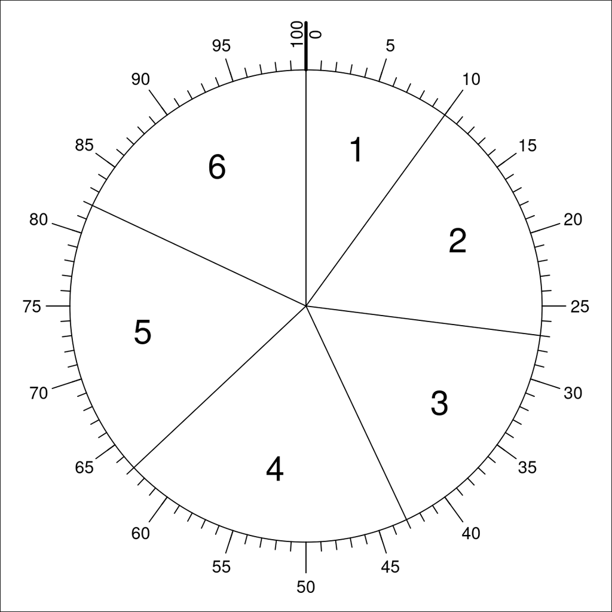

## Answerlist

- Evaluate $\#[\mathbf{x}<3.5]$.
- Evaluate $\#[\mathbf{x}>4.5]$.
- Evaluate $\#[|\mathbf{x}-2.5|<1]$.
- Evaluate $\#[|\mathbf{x}-5|>0.5]$.
- Evaluate half-integer boundary $b$ such that $\#[\mathbf{x}<b] = 43$.
- Evaluate half-integer boundary $b$ such that $\#[\mathbf{x}>b] = 37$.
- Evaluate integer radius $r$ such that $\#[|\mathbf{x}-2.5|<r] = 33$.
- Evaluate half-integer radius $r$ such that $\#[|\mathbf{x}-4|>r] = 80$.

# Solution

The first 4 questions involve adding up frequencies of the indicated intervals. The last 4 questions can be done by guessing and checking until something works.

## Answerlist

- There are 43 measurements less than 3.5. So, $\#[\mathbf{x}<3.5]=43$.
- There are 37 measurements more than 4.5. So, $\#[\mathbf{x}>4.5]=37$.
- There are 33 measurements closer than 1 units from 2.5. So, $\#[|\mathbf{x}-2.5|<1]=33$.
- There are 81 measurements further than 0.5 units from 5. So, $\#[|\mathbf{x}-5|>0.5]=81$.
- A boundary at $b=3.5$ has 43 measurements less than it. So, $\#[\mathbf{x}<3.5]=43$.
- A boundary at $b=4.5$ has 37 measurements more than it. So, $\#[\mathbf{x}>4.5]=37$.
- An interval with radius $r=1$ around center 2.5 contains 33 measurements. So, $\#[|\mathbf{x}-2.5|<1]=33$.
- An interval with radius $r=0.5$ around center 4 excludes 80 measurements. So, $\#[|\mathbf{x}-4|>0.5]=80$.

# Meta-information

extype: cloze exclozetype: num|num|num|num|num|num|num|num exsolution: 43|37|33|81|3.5|4.5|1|0.5 exname: read_circle_freq extol: 0 exextra[numwidth]: 999